# Identificando Interações em Experimentos Fatoriais

Professor: Cleanderson R. Fidelis

## Introdução

Nesta aula, aprenderemos a:

- Criar gráficos de interação para representar os efeitos de dois fatores em um experimento fatorial.
- Analisar dados experimentais para verificar se há interação entre os fatores.
- Representar croquis experimentais usando o pacote AgroR.

## Exemplo 1

Sejam os dados de um experimento, em blocos casualizados, no esquema fatorial $3 \times 3$, em que foram estudados os efeitos de **3 Peneiras comerciais**, associadas a **3 Densidades de plantio**, na produtividade do amendoim (*Arachis hypogaea L.*) variedade Tatu V53.

As **Peneiras comerciais (P)** e as **Densidades de plantio (D)** estudadas foram:

- $P_1$: peneira 18 (crivos circulares com diâmetro de 18/64 polegadas);
- $P_2$: peneira 20 (crivos circulares com diâmetro de 20/64 polegadas);
- $P_3$: peneira 22 (crivos circulares com diâmetro de 22/64 polegadas);
- $D_1$: 10 plantas por metro linear;
- $D_2$: 15 plantas por metro linear;
- $D_3$: 20 plantas por metro linear.

```r
# Caso 1: Experimento sem interação
# Conjunto de Dados
cat("### Caso 1: Experimento sem interação\n")
```

```
## ### Caso 1: Experimento sem interação
```

```r
dados_amendoim <- data.frame(
  Tratamentos = c("P1D1", "P1D2", "P1D3", "P2D1", "P2D2", "P2D3", "P3D1", "P3D2", "P3D3"),
  Peneira = as.factor(rep(c("P1", "P2", "P3"), each = 3)),
  Densidade = as.factor(rep(c("D1", "D2", "D3"), times = )),
  Blocos = as.factor(rep(c("Bloco1", "Bloco2", "Bloco3"), each = 9)),
  Producao = c(11.82, 12.34, 13.41, 6.97, 8.96, 8.48, 7.53, 6.71, 6.82,
               12.03, 14.08, 12.98, 10.26, 9.2, 9.66, 7.67, 7.87, 8.44,
               12.55, 12.13, 13.35, 9.02, 9.84, 8.50, 7.81, 9.49, 9.37)
)

print(dados_amendoim)
```

```
##    Tratamentos Peneira Densidade Blocos Producao
## 1         P1D1      P1        D1 Bloco1    11.82
## 2         P1D2      P1        D2 Bloco1    12.34
## 3         P1D3      P1        D3 Bloco1    13.41
## 4         P2D1      P2        D1 Bloco1     6.97
## 5         P2D2      P2        D2 Bloco1     8.96
## 6         P2D3      P2        D3 Bloco1     8.48
## 7         P3D1      P3        D1 Bloco1     7.53
## 8         P3D2      P3        D2 Bloco1     6.71
## 9         P3D3      P3        D3 Bloco1     6.82
## 10        P1D1      P1        D1 Bloco2    12.03
## 11        P1D2      P1        D2 Bloco2    14.08
## 12        P1D3      P1        D3 Bloco2    12.98
## 13        P2D1      P2        D1 Bloco2    10.26
## 14        P2D2      P2        D2 Bloco2     9.20
## 15        P2D3      P2        D3 Bloco2     9.66
## 16        P3D1      P3        D1 Bloco2     7.67
## 17        P3D2      P3        D2 Bloco2     7.87
## 18        P3D3      P3        D3 Bloco2     8.44
## 19        P1D1      P1        D1 Bloco3    12.55
## 20        P1D2      P1        D2 Bloco3    12.13
## 21        P1D3      P1        D3 Bloco3    13.35
## 22        P2D1      P2        D1 Bloco3     9.02
## 23        P2D2      P2        D2 Bloco3     9.84
## 24        P2D3      P2        D3 Bloco3     8.50
## 25        P3D1      P3        D1 Bloco3     7.81
## 26        P3D2      P3        D2 Bloco3     9.49
## 27        P3D3      P3        D3 Bloco3     9.37
```

## Construção do gráfico de interação

```r
# Calculando a produção média por tratamento
dados_media <- aggregate(Producao ~ Peneira + Densidade, data = dados_amendoim, FUN = mean)

# Visualizando os dados com médias
print(dados_media)
```

```
##   Peneira Densidade  Producao
## 1      P1        D1 12.133333
## 2      P2        D1  8.750000
## 3      P3        D1  7.670000
## 4      P1        D2 12.850000
## 5      P2        D2  9.333333
## 6      P3        D2  8.023333
## 7      P1        D3 13.246667
## 8      P2        D3  8.880000
## 9      P3        D3  8.210000
```

O gráfico de interação é utilizado para verificar visualmente a presença de interação entre os fatores.

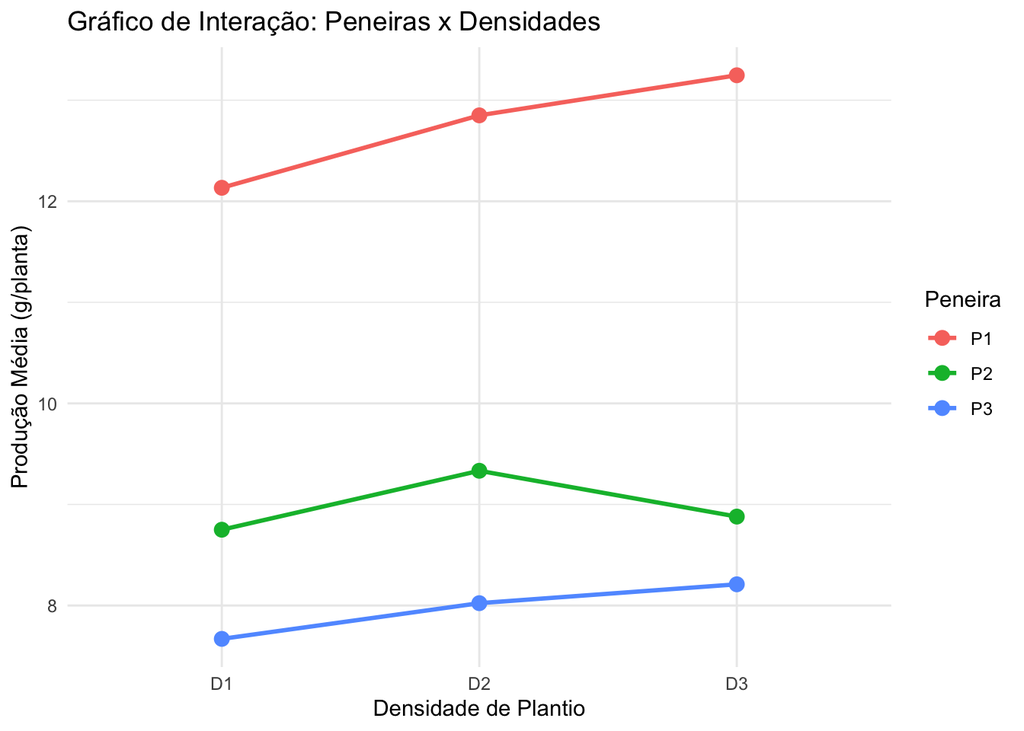

```r
# Gráfico de Interação com Produção Média
library(ggplot2)
ggplot(dados_media, aes(x = Densidade, y = Producao, color = Peneira, group = Peneira)) +
  geom_line(size = 1) +
  geom_point(size = 3) +
  labs(
    title = "Gráfico de Interação: Peneiras x Densidades",
    x = "Densidade de Plantio",
    y = "Produção Média (g/planta)"
  ) +
  theme_minimal()
```

As linhas paralelas indicam ausência de interação significativa entre os fatores.

## Croqui experimental

O croqui experimental apresenta visualmente o delineamento do experimento.

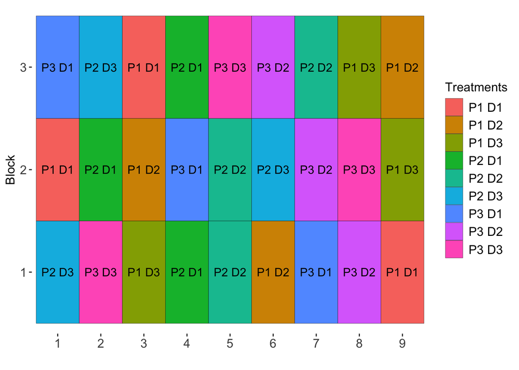

```r
# Croqui Experimental
library(AgroR)
sketch(trat=c("P1","P2","P3"),#paste("D",rep(1:3,3)),
       trat1=c("D1","D2","D3"),#paste("P",rep(1:3,3)),
       design = "fat2dbc",
       r=3)
```

## Análise de variância utilizando o pacote ExpDes.pt

Utilizamos a função *fat2.dbc* para ajustar o modelo estatístico, considerando os fatores qualitativos.

```r
# carregando o pacote ExpDes.pt
library(ExpDes.pt)

attach(dados_amendoim)

fat2.dbc(
  Peneira,
  Densidade,
  Blocos,
  Producao,
  quali = c(TRUE, TRUE),
  mcomp = "tukey",
  fac.names = c("Peneira", "Densidade"),
  sigT = 0.05,
  sigF = 0.05
)
```

```
## ------------------------------------------------------------------------
## Legenda:
## FATOR 1:  Peneira
## FATOR 2:  Densidade
## ------------------------------------------------------------------------
##
##
## Quadro da analise de variancia
## ------------------------------------------------------------------------
##                   GL      SQ QM     Fc   Pr>Fc
## Bloco              2   6.115  5  4.578 0.02678
## Peneira            2 113.852  6 85.243 0.00000
## Densidade          2   1.977  4  1.480 0.25716
## Peneira*Densidade  4   0.948  2  0.355 0.83698
## Residuo           16  10.685  3
## Total             26 133.576  1
## ------------------------------------------------------------------------
## CV = 8.25 %
##
## ------------------------------------------------------------------------
## Teste de normalidade dos residuos (Shapiro-Wilk)
## valor-p:  0.5912535
## De acordo com o teste de Shapiro-Wilk a 5% de significancia, os residuos podem ser considerados normais.
## ------------------------------------------------------------------------
##
## Interacao nao significativa: analisando os efeitos simples
## ------------------------------------------------------------------------
## Peneira
## Teste de Tukey
## ------------------------------------------------------------------------
## Grupos Tratamentos Medias
## a     P1      12.74333
##  b    P2      8.987778
##   c   P3      7.967778
## ------------------------------------------------------------------------
##
## Densidade
## De acordo com o teste F, as medias desse fator sao estatisticamente iguais.
## ------------------------------------------------------------------------
##   Niveis    Medias
## 1     D1  9.517778
## 2     D2 10.068889
## 3     D3 10.112222
## ------------------------------------------------------------------------
```

```r
detach(dados_amendoim)
```

## Análise de Variância utilizando o pacote AgroR

Utilizamos a função *FAT2DBC* para ajustar o modelo estatístico, considerando os fatores qualitativos.

```r
# carregando o pacote AgroR
library(AgroR)
with(dados_amendoim,
     FAT2DBC(f1 = Densidade,
             f2 = Peneira,
             block = Blocos,
             Producao,
             ylab="Produção",
             names.fat = c("Densidade", "Peneira"),
             legend = "Densidade",
             fill = "trat"))
```

```
##
## -----------------------------------------------------------------
## Normality of errors
## -----------------------------------------------------------------
##                          Method Statistic   p.value
##  Shapiro-Wilk normality test(W) 0.9695991 0.5912535
##
##
## -----------------------------------------------------------------
## Homogeneity of Variances
## -----------------------------------------------------------------
##                               Method Statistic   p.value
##  Bartlett test(Bartlett's K-squared)   3.70341 0.8828428
##
##
## -----------------------------------------------------------------
## Independence from errors
## -----------------------------------------------------------------
##                  Method Statistic  p.value
##  Durbin-Watson test(DW)  2.429306 0.348919
##
##
## -----------------------------------------------------------------
## Additional Information
## -----------------------------------------------------------------
##
## CV (%) =  8.25
## Mean =  9.8996
## Median =  9.37
## Possible outliers =  No discrepant point
##
## -----------------------------------------------------------------
## Analysis of Variance
## -----------------------------------------------------------------
##                     Df      Sum Sq    Mean.Sq    F value        Pr(F)
## Densidade            2   1.9768963  0.9884481  1.4801477 2.571574e-01
## Peneira              2 113.8515852 56.9257926 85.2433017 2.936153e-09
## Block                2   6.1148074  3.0574037  4.5782970 2.677596e-02
## Densidade × Peneira  4   0.9475481  0.2368870  0.3547256 8.369789e-01
## Residuals           16  10.6848593  0.6678037
```

[output cut: 8 more lines]

```
## Multiple Comparison Test: Tukey HSD
##         resp groups
## P1 12.743333      a
## P2  8.987778      b
## P3  7.967778      c
##
##
##
## -----------------------------------------------------------------
## Isolated factors 1 not significant
## -----------------------------------------------------------------
##         Mean
## D1  9.517778
## D2 10.068889
## D3 10.112222
```

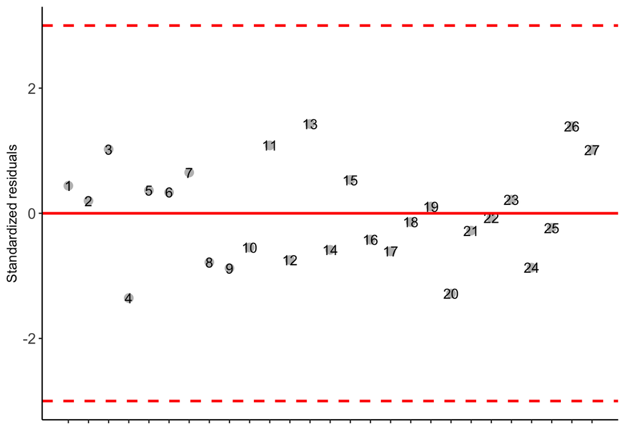

```
##
## $graph1
## [1] 2
##
## $graph2
```

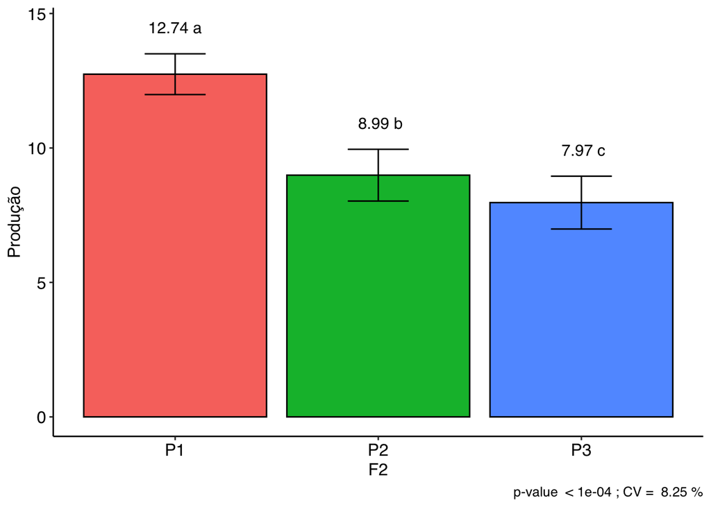